# Cyclistic bike-share analysis

Case Study: How Does a Bike-Share Navigate Speedy Success?

Eric Davis

2023-05-12

## Scenario

You are a junior data analyst working in the marketing analyst team at Cyclistic, a bike-share company in Chicago. The director of marketing believes the company’s future success depends on maximizing the number of annual memberships. Therefore, your team wants to understand how casual riders and annual members use Cyclistic bikes differently. From these insights, your team will design a new marketing strategy to convert casual riders into annual members. But first, Cyclistic executives must approve your recommendations, so they must be backed up with compelling data insights and professional data Visualizations.

## Characters and teams

- Cyclistic: A bike-share program that features more than 5,800 bicycles and 600 docking stations. Cyclistic sets itself apart by also offering reclining bikes, hand tricycles, and cargo bikes, making bike-share more inclusive to people with disabilities and riders who can’t use a standard two-wheeled bike.
- The majority of riders opt for traditional bikes; about 8% of riders use the assistive options.
- Cyclistic users are more likely to ride for leisure, but about 30% use them to commute to work each day.
- Lily Moreno: The director of marketing and your manager. Moreno is responsible for the development of campaigns and initiatives to promote the bike-share program. These may include email, social media, and other channels.
- Cyclistic marketing analytics team: A team of data analysts who are responsible for collecting, analyzing, and reporting data that helps guide Cyclistic marketing strategy.
- You joined this team six months ago and have been busy learning about Cyclistic’s mission and business goals — as well as how you, as a junior data analyst, can help Cyclistic achieve them.
- Cyclistic executive team: The notoriously detail-oriented executive team will decide whether to approve the recommended marketing program.

## About the company

In 2016, Cyclistic launched a successful bike-share offering. Since then, the program has grown to a fleet of 5,824 bicycles that are geotracked and locked into a network of 692 stations across Chicago. The bikes can be unlocked from one station and returned to any other station in the system anytime. Until now, Cyclistic’s marketing strategy relied on building general awareness and appealing to broad consumer segments. One approach that helped make these things possible was the flexibility of its pricing plans: single-ride passes, full-day passes, and annual memberships. Customers who purchase single-ride or full-day passes are referred to as casual riders. Customers who purchase annual memberships are Cyclistic members. Cyclistic’s finance analysts have concluded that annual members are much more profitable than casual riders. Although the pricing flexibility helps Cyclistic attract more customers, Moreno believes that maximizing the number of annual members will be key to future growth. Rather than creating a marketing campaign that targets all-new customers, Moreno believes there is a very good chance to convert casual riders into members. She notes that casual riders are already aware of the Cyclistic program and have chosen Cyclistic for their mobility needs.

# Ask

Cyclistic wants to understand how casual riders and annual members use their bikes differently to design a new marketing strategy that will convert casual riders into annual members. The business task is to analyze Cyclistic’s historical bike trip data to identify differences between the two user groups.

Guiding question for the Ask stage of the data analysis process:

- How do annual members and casual riders use Cyclistic bikes differently?

# Prepare

### Data

Data Source: https://divvy-tripdata.s3.amazonaws.com/index.html

### Packages

```r
library(tidyverse)
library(geosphere)
library(lubridate)
```

I downloaded all csv files with 2022 in the folder name. I then read in all csv files into one data frame “combined_df”

```r
# Set the directory path where your CSV files are located
directory_path <- "~/Coursera/Case Study 1 How does a bike-share navigate speedy success/unzipped"

# Get a list of all CSV files in the directory
csv_files <- list.files(directory_path, pattern = "\\.csv$", full.names = TRUE)

# Create an empty list to store individual data frames
data_frames <- list()

# Loop through each CSV file and read it into a data frame
for (file in csv_files) {
  data <- read.csv(file)
  data_frames[[file]] <- data
}

# Combine all data frames into a single data frame
combined_df <- do.call(rbind, data_frames)
```

```r
# Summary of combined_df
summary(combined_df)
```

```
##    ride_id          rideable_type       started_at          ended_at
##  Length:5733451     Length:5733451     Length:5733451     Length:5733451
##  Class :character   Class :character   Class :character   Class :character
##  Mode  :character   Mode  :character   Mode  :character   Mode  :character
##
##
##
##
##  start_station_name start_station_id   end_station_name   end_station_id
##  Length:5733451     Length:5733451     Length:5733451     Length:5733451
##  Class :character   Class :character   Class :character   Class :character
##  Mode  :character   Mode  :character   Mode  :character   Mode  :character
##
##
##
##
##    start_lat       start_lng         end_lat         end_lng
##  Min.   :41.64   Min.   :-87.84   Min.   : 0.00   Min.   :-88.14
##  1st Qu.:41.88   1st Qu.:-87.66   1st Qu.:41.88   1st Qu.:-87.66
##  Median :41.90   Median :-87.64   Median :41.90   Median :-87.64
##  Mean   :41.90   Mean   :-87.65   Mean   :41.90   Mean   :-87.65
##  3rd Qu.:41.93   3rd Qu.:-87.63   3rd Qu.:41.93   3rd Qu.:-87.63
##  Max.   :45.64   Max.   :-73.80   Max.   :42.37   Max.   :  0.00
##                                   NA's   :5874    NA's   :5874
##  member_casual
##  Length:5733451
##  Class :character
##  Mode  :character
##
##
##
##
```

There is 5874 NA’s in the end_lat & _lng columns.

# Process

### Data Cleaning

I will manipulate and explore the data by performing the following steps:

```r
# Calculate the ride duration in minutes / new column ride_duration
combined_df$ride_duration <- as.numeric(difftime(combined_df$ended_at, combined_df$started_at, units = "mins"))
```

```r
summary(combined_df$ride_duration)
```

```
##      Min.   1st Qu.    Median      Mean   3rd Qu.      Max.
## -10353.35      5.83     10.30     19.42     18.50  41387.25
```

It appears that there might be some issues with the ride duration values. The minimum value of -10353.35 and the maximum value of 41387.25 seem unusual for ride duration in minutes.

```r
# Create new column for day of the week
combined_df <- combined_df %>%
  mutate(day_of_week = wday(started_at, label = TRUE))
```

```r
summary(combined_df$day_of_week)
```

```
##    Sun    Mon    Tue    Wed    Thu    Fri    Sat
## 782632 757407 782733 817125 854086 817407 922061
```

```r
## Adding distance_meters & distance_miles columns

# Calculate distance in meters between start and end coordinates
combined_df$distance_meters <- distGeo(
  cbind(combined_df$start_lng, combined_df$start_lat),
  cbind(combined_df$end_lng, combined_df$end_lat)
)

# Convert distance in meters to miles
combined_df$distance_miles <- combined_df$distance_meters * 0.000621371
```

```r
summary(combined_df$distance_meters)
```

```
##    Min. 1st Qu.  Median    Mean 3rd Qu.    Max.    NA's
##       0     873    1576    2142    2784 9817319    5874
```

```r
summary(combined_df$distance_miles)
```

```
##     Min.  1st Qu.   Median     Mean  3rd Qu.     Max.     NA's
##    0.000    0.543    0.979    1.331    1.730 6100.198     5874
```

It appears that there might be some outliers within the distance_ values.

To identify and potentially remove distance outliers from the combined_df data frame, I will use a common technique z-scores to identify observations that are significantly different from the mean. Here’s how I chose to identify and handle outliers:

```r
# Calculate z-scores for the distance_miles column
z_scores <- scale(combined_df$distance_miles)

# Define a threshold for distance outliers (e.g., z-score greater than 3 or less than -3)
threshold <- 3

# Identify rows with distance outliers
outlier_rows <- abs(z_scores) > threshold

# Count the number of outliers
num_outliers <- sum(outlier_rows)

# Optionally, you can remove the outliers from the combined_df data frame
combined_df <- combined_df[!outlier_rows, ]
```

```r
summary(combined_df$distance_miles)
```

```
##    Min. 1st Qu.  Median    Mean 3rd Qu.    Max.    NA's
##   0.000   0.543   0.979   1.322   1.730  22.968    5874
```

```r
# Calculate z-scores for the distance_meters column
z_scores_distance <- scale(combined_df$distance_meters)

# Define a threshold for distance_meters outliers (e.g., z-score greater than 3 or less than -3)
threshold_distance <- 3

# Identify rows with distance_meters outliers
outlier_rows_distance <- abs(z_scores_distance) > threshold_distance

# Count the number of distance_meters outliers
num_outliers_distance <- sum(outlier_rows_distance)

# Optionally, you can remove the outliers from the combined_df data frame
combined_df <- combined_df[!outlier_rows_distance, ]
```

```r
summary(combined_df$distance_meters)
```

```
##    Min. 1st Qu.  Median    Mean 3rd Qu.    Max.    NA's
##     0.0   862.5  1541.8  1974.3  2700.0  7914.4    5874
```

```r
# Calculate z-scores for the ride_duration column
z_scores_duration <- scale(combined_df$ride_duration)

# Define a threshold for ride_duration outliers (e.g., z-score greater than 3 or less than -3)
threshold_duration <- 3

# Identify rows with ride_duration outliers
outlier_rows_duration <- abs(z_scores_duration) > threshold_duration

# Count the number of ride_duration outliers
num_outliers_duration <- sum(outlier_rows_duration)

# Optionally, you can remove the outliers from the combined_df data frame
combined_df <- combined_df[!outlier_rows_duration, ]
```

```r
summary(combined_df$ride_duration)
```

```
##    Min. 1st Qu.  Median    Mean 3rd Qu.    Max.    NA's
## -127.02    5.75   10.05   14.57   17.63  159.90    5874
```

I noticed negative ride_duration:

```r
## Remove negative duration values from the combined_df data frame
combined_df <- combined_df[combined_df$ride_duration >= 0, ]
```

```r
summary(combined_df$ride_duration)
```

```
##    Min. 1st Qu.  Median    Mean 3rd Qu.    Max.    NA's
##    0.00    5.75   10.05   14.57   17.63  159.90    5874
```

```r
# Check for duplicates in the combined_df dataset
duplicates <- duplicated(combined_df)

# Count the number of duplicates
num_duplicates <- sum(duplicates)

# Remove duplicated rows
#combined_df <- combined_df[!duplicated(combined_df), ]
```

There doesn’t appear to be any duplicates.

```r
# Convert the ride_duration column to numeric and the started_at and ended_at columns to date/time
combined_df$ride_duration <- as.numeric(combined_df$ride_duration)
combined_df$started_at <- as.POSIXct(combined_df$started_at)
combined_df$ended_at <- as.POSIXct(combined_df$ended_at)
```

```r
# round distance_meters, distance_miles, and duration_min columns to 2 decimal places
combined_df$distance_meters <- round(combined_df$distance_meters, 2)
combined_df$distance_miles <- round(combined_df$distance_miles, 2)
combined_df$ride_duration <- round(combined_df$ride_duration, 2)
```

```r
# Remove rows with NA values from the combined_df data frame
combined_df <- na.omit(combined_df)
```

```r
# Summary of combined_df
summary(combined_df)
```

```
##    ride_id          rideable_type        started_at
##  Length:5598567     Length:5598567     Min.   :2021-12-01 00:00:01.00
##  Class :character   Class :character   1st Qu.:2022-05-17 09:24:22.00
##  Mode  :character   Mode  :character   Median :2022-07-14 05:53:54.00
##                                        Mean   :2022-07-06 06:17:05.46
##                                        3rd Qu.:2022-09-07 20:00:07.50
##                                        Max.   :2022-11-30 23:56:11.00
##
##     ended_at                      start_station_name start_station_id
##  Min.   :2021-12-01 00:02:40.00   Length:5598567     Length:5598567
##  1st Qu.:2022-05-17 09:36:48.00   Class :character   Class :character
##  Median :2022-07-14 06:02:05.00   Mode  :character   Mode  :character
##  Mean   :2022-07-06 06:31:39.94
##  3rd Qu.:2022-09-07 20:13:14.50
##  Max.   :2022-12-01 00:21:10.00
##
##  end_station_name   end_station_id       start_lat       start_lng
##  Length:5598567     Length:5598567     Min.   :41.64   Min.   :-87.84
##  Class :character   Class :character   1st Qu.:41.88   1st Qu.:-87.66
##  Mode  :character   Mode  :character   Median :41.90   Median :-87.64
##                                        Mean   :41.90   Mean   :-87.65
##                                        3rd Qu.:41.93   3rd Qu.:-87.63
##                                        Max.   :42.07   Max.   :-87.52
##
##     end_lat         end_lng       member_casual      ride_duration
##  Min.   :41.63   Min.   :-87.87   Length:5598567     Min.   :  0.00
##  1st Qu.:41.88   1st Qu.:-87.66   Class :character   1st Qu.:  5.75
##  Median :41.90   Median :-87.64   Mode  :character   Median : 10.05
##  Mean   :41.90   Mean   :-87.65                      Mean   : 14.57
##  3rd Qu.:41.93   3rd Qu.:-87.63                      3rd Qu.: 17.63
##  Max.   :42.12   Max.   :-87.50                      Max.   :159.90
##
##  day_of_week  distance_meters  distance_miles
##  Sun:761032   Min.   :   0.0   Min.   :0.000
##  Mon:740134   1st Qu.: 863.8   1st Qu.:0.540
##  Tue:766067   Median :1543.0   Median :0.960
##  Wed:800374   Mean   :1975.5   Mean   :1.227
##  Thu:835662   3rd Qu.:2701.1   3rd Qu.:1.680
##  Fri:799345   Max.   :7914.4   Max.   :4.920
##  Sat:895953
```

# Analyze

These lines of code perform various analyses on the data

```r
# Filter the data for annual members and casual riders separately
annual_members <- combined_df[combined_df$member_casual == "member", ]
casual_riders <- combined_df[combined_df$member_casual == "casual", ]
```

```r
# Calculate the average ride duration for annual members and casual riders
avg_ride_duration <- tapply(annual_members$ride_duration, annual_members$day_of_week, mean)
avg_ride_duration_casual <- tapply(casual_riders$ride_duration, casual_riders$day_of_week, mean)
```

```r
# Show avg_duration (members) in min.
avg_ride_duration
```

```
##      Sun      Mon      Tue      Wed      Thu      Fri      Sat
## 12.67290 11.10291 10.93031 10.99170 11.14708 11.31328 12.73792
```

```r
# Show avg_duration_casual (casual) in min.
avg_ride_duration_casual
```

```
##      Sun      Mon      Tue      Wed      Thu      Fri      Sat
## 21.59413 19.51287 17.21999 16.71196 17.16798 17.98122 21.21890
```

```r
# Calculate the average distance for annual members and casual riders
avg_distance <- tapply(annual_members$distance_miles, annual_members$day_of_week, mean)
avg_distance_casual <- tapply(casual_riders$distance_miles, casual_riders$day_of_week, mean)
```

```r
# Show avg_distance (members) in Mi.
avg_distance
```

```
##      Sun      Mon      Tue      Wed      Thu      Fri      Sat
## 1.241133 1.184264 1.196071 1.206022 1.214015 1.195181 1.267874
```

```r
# Show avg_distance_casual (casual) in Mi.
avg_distance_casual
```

```
##      Sun      Mon      Tue      Wed      Thu      Fri      Sat
## 1.270353 1.202454 1.212349 1.223719 1.236801 1.242173 1.303208
```

### Visualize

These codes generates visualizations from the dataset.

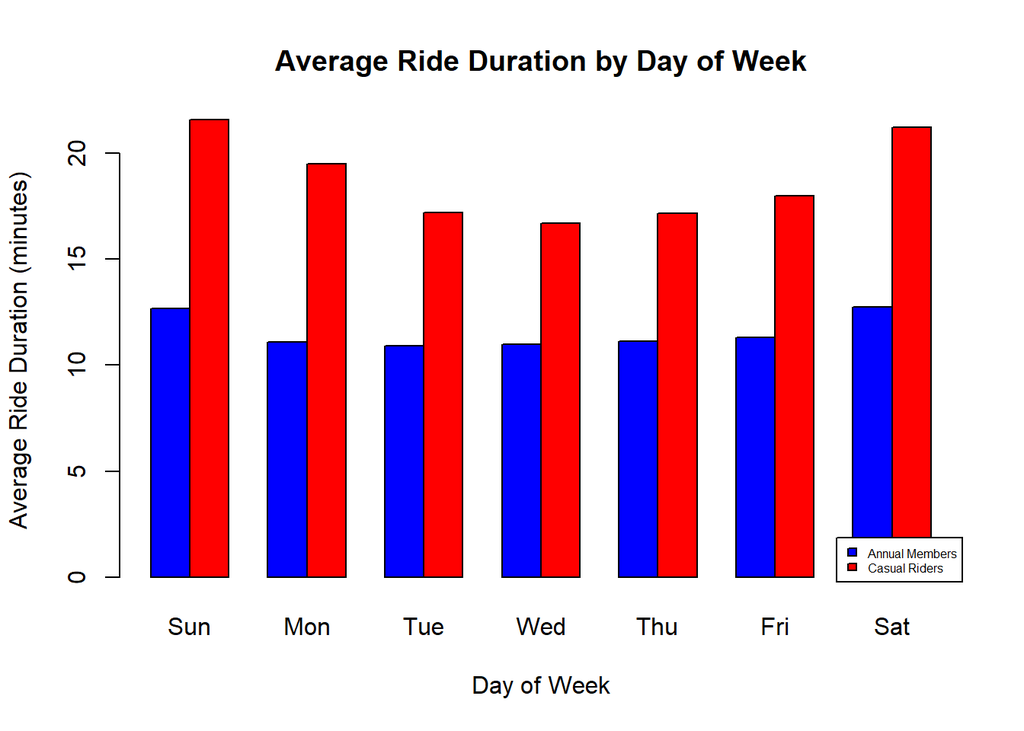

```r
# Create a bar plot to compare the average ride duration between annual members and casual riders
barplot(rbind(avg_ride_duration, avg_ride_duration_casual),
        beside = TRUE,
        names.arg = c("Sun", "Mon", "Tue", "Wed", "Thu", "Fri", "Sat"),
        xlab = "Day of Week",
        ylab = "Average Ride Duration (minutes)",
        main = "Average Ride Duration by Day of Week",
        col = c("blue", "red"))

# Manually position and adjust the size of the legend
legend("bottomright",
       legend = c("Annual Members", "Casual Riders"),
       fill = c("blue", "red"),
       cex = 0.5)  # Adjust the value of cex to make the legend smaller
```

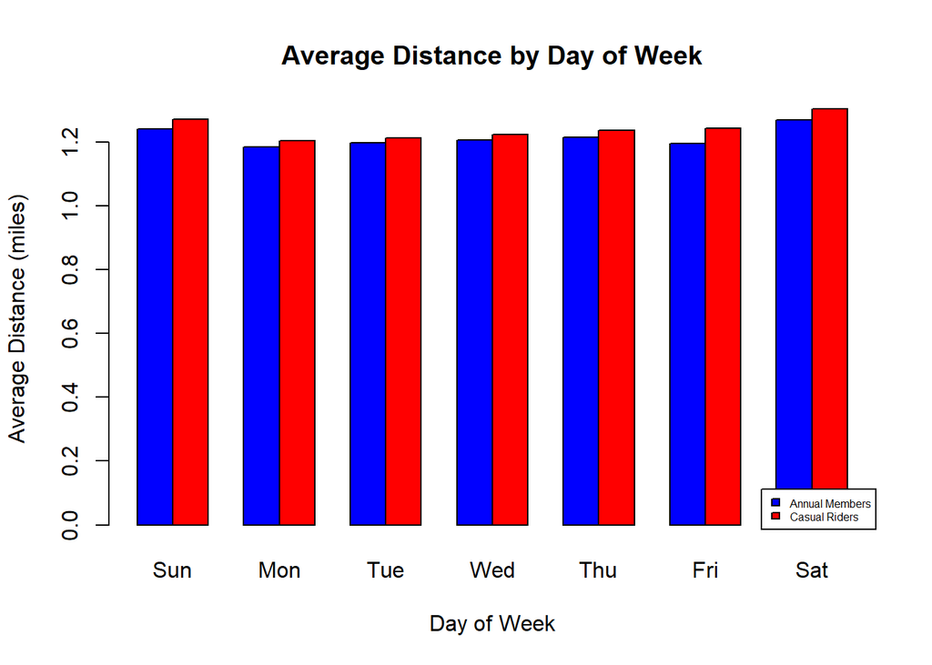

```r
# Create a bar plot to compare the average distance between annual members and casual riders
barplot(rbind(avg_distance, avg_distance_casual),
        beside = TRUE,
        names.arg = c("Sun", "Mon", "Tue", "Wed", "Thu", "Fri", "Sat"),
        xlab = "Day of Week",
        ylab = "Average Distance (miles)",
        main = "Average Distance by Day of Week",
        col = c("blue", "red"))

# Manually position and adjust the size of the legend
legend("bottomright",
       legend = c("Annual Members", "Casual Riders"),
       fill = c("blue", "red"),
       cex = 0.5)  # Adjust the value of cex to make the legend smaller
```

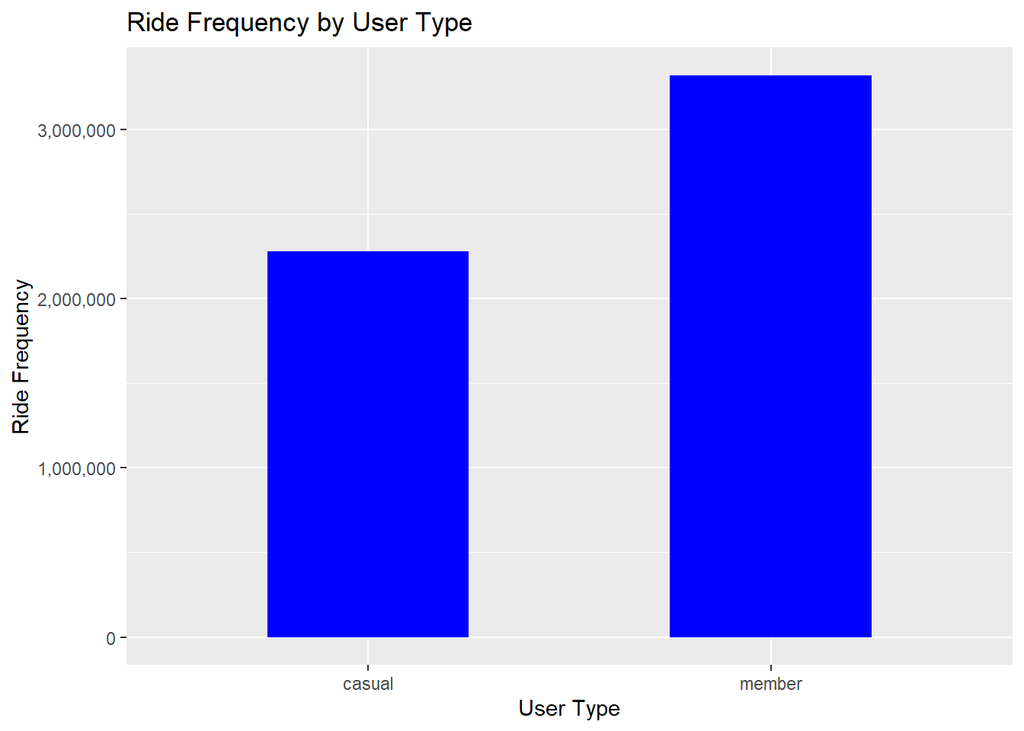

```r
# Calculate the ride frequency for annual members and casual riders
ride_frequency <- table(combined_df$member_casual)

# Plotting the ride frequency
ggplot(data = NULL, aes(x = factor(names(ride_frequency)), y = ride_frequency)) +
  geom_bar(stat = "identity", fill = "blue", width = 0.5) +
  labs(x = "User Type", y = "Ride Frequency", title = "Ride Frequency by User Type") +
  scale_y_continuous(labels = scales::comma)
```

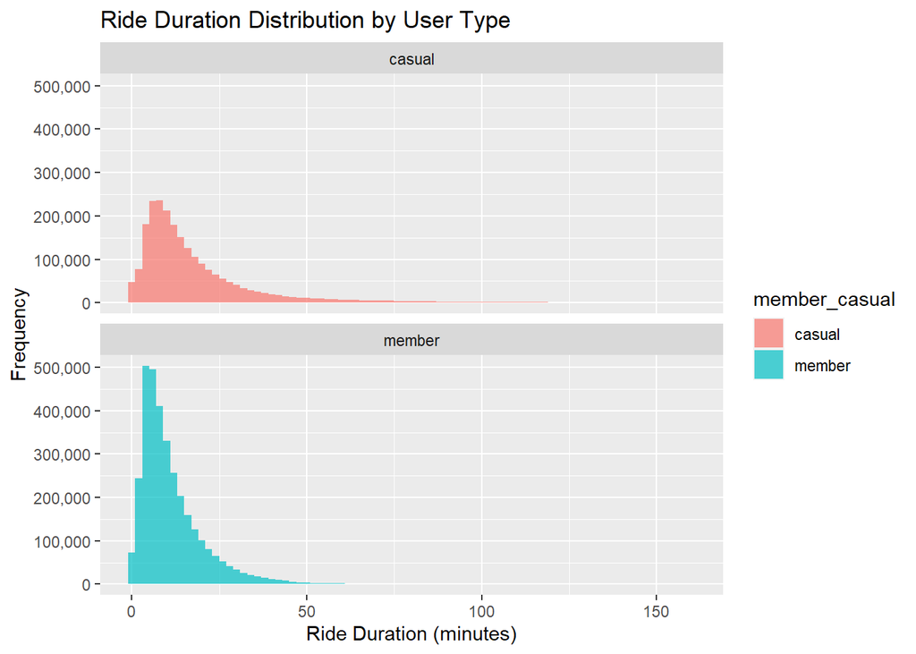

```r
# Plotting histograms for ride duration distribution
ggplot(combined_df, aes(x = ride_duration, fill = member_casual)) +
  geom_histogram(binwidth = 2, position = "identity", alpha = 0.7) +
  facet_wrap(~ member_casual, ncol = 1) +
  labs(x = "Ride Duration (minutes)", y = "Frequency", title = "Ride Duration Distribution by User Type") +
  scale_x_continuous(labels = scales::comma) +
  scale_y_continuous(labels = scales::comma)
```

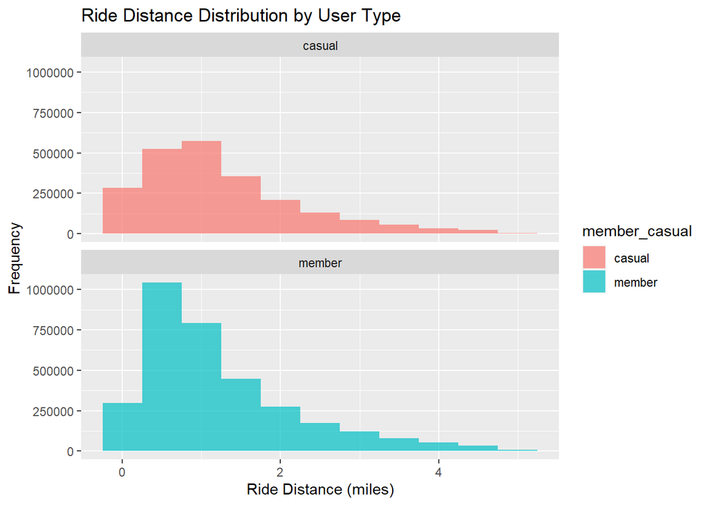

```r
# Plotting histograms for ride distance distribution
ggplot(combined_df, aes(x = distance_miles, fill = member_casual)) +
  geom_histogram(binwidth = 0.5, position = "identity", alpha = 0.7) +
  facet_wrap(~ member_casual, ncol = 1) +
  labs(x = "Ride Distance (miles)", y = "Frequency", title = "Ride Distance Distribution by User Type")
```

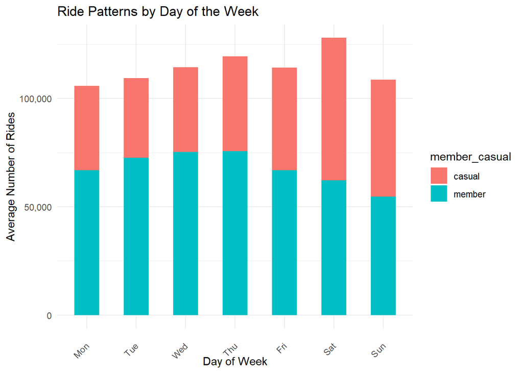

```r
# Calculate the average number of rides per day for annual members and casual riders
ride_counts_by_day <- combined_df %>%
  group_by(member_casual, day_of_week) %>%
  summarise(ride_count = n()) %>%
  mutate(ride_count_avg = ride_count / n_distinct(day_of_week))

# Define the order of the days of the week
day_order <- c("Mon", "Tue", "Wed", "Thu", "Fri", "Sat", "Sun")

# Create a bar plot to visualize ride patterns by the day of the week
ggplot(ride_counts_by_day, aes(x = day_of_week, y = ride_count_avg, fill = member_casual)) +
  geom_bar(stat = "identity", width = 0.5) +
  labs(x = "Day of Week", y = "Average Number of Rides", title = "Ride Patterns by Day of the Week") +
  scale_x_discrete(limits = day_order) +
  scale_y_continuous(labels = scales::comma) +  # Format y-axis labels with commas
  theme_minimal() +
  theme(axis.text.x = element_text(angle = 45, vjust = 0.5, hjust = 1))
```

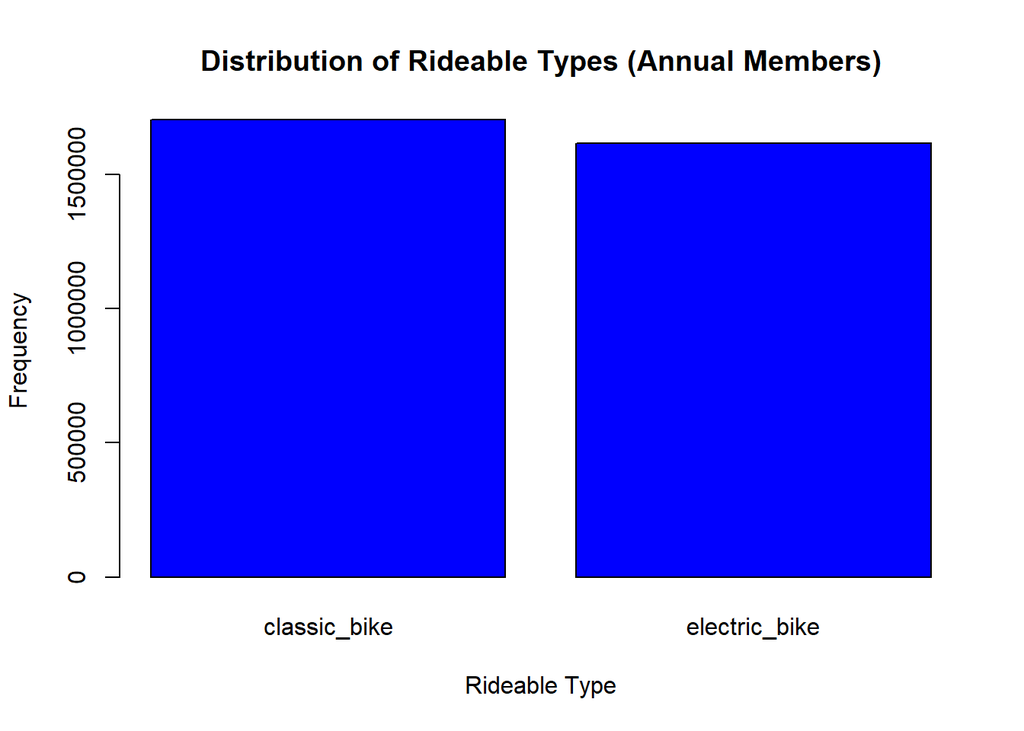

```r
# Calculate the frequency of each rideable type for annual members and casual riders
rideable_type_frequency_members <- table(annual_members$rideable_type)
rideable_type_frequency_casual <- table(casual_riders$rideable_type)

# Plotting the distribution of rideable types for annual members
barplot(rideable_type_frequency_members,
        main = "Distribution of Rideable Types (Annual Members)",
        xlab = "Rideable Type",
        ylab = "Frequency",
        col = "blue")
```

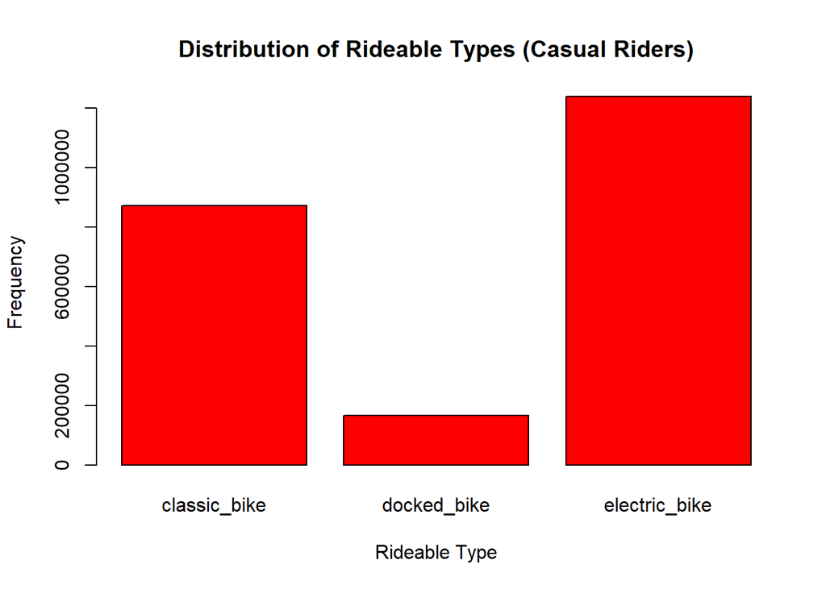

```r
# Plotting the distribution of rideable types for casual riders
barplot(rideable_type_frequency_casual,
        main = "Distribution of Rideable Types (Casual Riders)",
        xlab = "Rideable Type",
        ylab = "Frequency",
        col = "red")
```

# Share

### How do annual members and casual riders use Cyclistic bikes differently?

# Act

### Recommendations

Based on the findings, the following recommendations can be made:

1. **Targeted Marketing**: Develop targeted marketing campaigns to attract more annual members, highlighting the benefits of membership such as shorter ride durations and cost-effectiveness for regular riders.
2. **Improving Convenience**: To encourage casual riders to become annual members, consider providing additional conveniences such as flexible subscription plans, discounted rates for frequent riders, or loyalty rewards.
3. **Expand Bike Availability**: Since casual riders tend to use the bikes for longer durations and distances, ensure an adequate supply of bikes in popular areas to meet their needs.

### Future Work

To gain further insights and improve the analysis, the following avenues can be explored in future work:

1. **Demographic Analysis**: Conduct a demographic analysis to understand how different customer segments utilize Cyclistic bikes and tailor the marketing strategies accordingly.
2. **Customer Surveys**: Conduct surveys or interviews to gather qualitative data from customers about their preferences, needs, and satisfaction levels to complement the quantitative analysis.
3. **Seasonal Analysis**: Perform a comparative analysis across different seasons to identify any seasonal variations in bike usage and inform operational planning and resource allocation.

# Conclusion

The analysis of Cyclistic bike usage data provides valuable insights into the differences between annual members and casual riders. The findings highlight that casual riders tend to ride for longer durations, cover greater distances per ride, and constitute a significant portion of Cyclistic’s customer base.

The key takeaway is that there is a distinct usage pattern between these two groups, suggesting different motivations and preferences for bike usage. Annual members may be more inclined towards shorter and more frequent rides, potentially using the bikes for daily commuting or short trips. On the other hand, casual riders appear to utilize the bikes for longer trips, indicating a preference for recreational or leisurely purposes.

Based on these findings, recommendations have been proposed to enhance the Cyclistic bike-sharing program. Targeted marketing efforts should be employed to attract more annual members, while also considering the convenience factors that could incentivize casual riders to become annual members. Furthermore, ensuring an adequate supply of bikes in popular areas is crucial to meet the demand from both groups.

It is important to acknowledge the limitations of the analysis, such as the specific time period considered and the potential impact of data anomalies or inconsistencies. Additionally, future work can focus on conducting a demographic analysis, gathering qualitative data through customer surveys, and performing seasonal analyses to further enhance our understanding of bike usage patterns.

Overall, the insights gained from this analysis can aid Cyclistic in optimizing their operations, improving customer satisfaction, and tailoring their services to better meet the needs of their diverse customer base.